# Module 4 Data Analysis

Ashwin

2025-09-25

# Introduction

Sharks sit at the top of marine food webs and have a major influence on how ecosystems function (Heupel et al., 2014). When their numbers are reduced, the effects ripple down through the system, sometimes leading to increases in mid-level predators and losses in prey diversity. At the same time, the presence of sharks has created tension with people, especially in coastal areas where swimming and surfing are common and the risk of attack is part of the public mindset.

To address these concerns, Queensland launched the Shark Control Program (SCP) back in 1962. The program relies on nets and drumlines along busy beaches with the aim of lowering shark–human encounters (Queensland Government, 2024). It has been credited with reducing incidents, but the trade-off is substantial. Critics point to shark deaths and the unintended capture of turtles, dugongs, dolphins, and other species that are not the program’s targets (Sumpton et al., 2011; Gibbs & Warren, 2014).

Catch data from the program are compiled in the QFISH database, maintained by the Department of Agriculture and Fisheries. This long-term record is a key resource for looking at how shark numbers have shifted over time and across regions. For the current project, we use records from 2001 through to 2025, focusing only on sharks. The dataset reports annual catches by region, which makes it possible to track trends over time and to compare how patterns differ between areas.

# Part 1: Data acquisition

- Data source: Queensland Government QFISH database
- Dataset selected: *Shark Control Program – Number caught by area, calendar year and species group* (https://qfish.fisheries.qld.gov.au/query/number-caught-by-area-calendaryear-and-species-group/table#)
- Exported as CSV and stored in my repository under `data/`.

```r
library(tidyverse)
# Import the raw data
raw_data <- read_csv("C:/Users/Ashwin/Desktop/Module 4/Module-4-data-analysis-/Data/Qfishdata.csv")
```

```
## ──────────────────────────────────────────────────────── Delimiter: "," chr
## (127): CalendarYear, 2001...2, 2001...3, 2001...4, 2001...5, 2001...6, 2...
```

Part 2: Tidy the data

For this project we narrow it down to the shark data. The records are grouped by year and by region, so the catches can be looked at both over time and across different areas.

```r
# 2. First row contains species groups (Mammal, Other, Shark, Turtle, Total)
#    Extract those labels and build proper column names
categories <- raw_data[1, -1] |> as.character()
year_cols <- names(raw_data)[-1]

# Create a dataframe with multi-index-like names: Year.Category
colnames(raw_data) <- c("Area", paste(year_cols, categories, sep = "_"))

# 3. Drop the first row (species header row)
raw_data <- raw_data[-1, ]

# 4. Keep only Shark columns
shark_cols <- c("Area", grep("_Shark$", names(raw_data), value = TRUE))
shark_data <- raw_data[ , shark_cols]

# 5. Reshape to tidy format
shark_tidy <- shark_data |>
  pivot_longer(
    cols = -Area,
    names_to = "Year",
    values_to = "Shark"
  ) |>
  # Extract just the year number from e.g. "2001_Shark"
  mutate(
    Year = str_extract(Year, "^[0-9]{4}") |> as.integer(),
    Shark = as.numeric(Shark)
  )

# 6. Remove Grand Total row and replace NAs with 0
shark_tidy <- shark_tidy |>
  filter(Area != "Grand Total") |>
  mutate(Shark = replace_na(Shark, 0))

# Inspect cleaned dataset
head(shark_tidy)
```

```
## # A tibble: 6 × 3
##   Area           Year Shark
##   <chr>         <int> <dbl>
## 1 Bribie Island  2001     0
## 2 Bribie Island  2002     0
## 3 Bribie Island  2003     0
## 4 Bribie Island  2004     0
## 5 Bribie Island  2005     0
## 6 Bribie Island  2006     0
```

Part 3: Exploratory analysis and plotting

The next step is to look at the data in a simple way. We put together a time-series plot of shark catches, with the records broken out by region so the changes through time are easier to see.

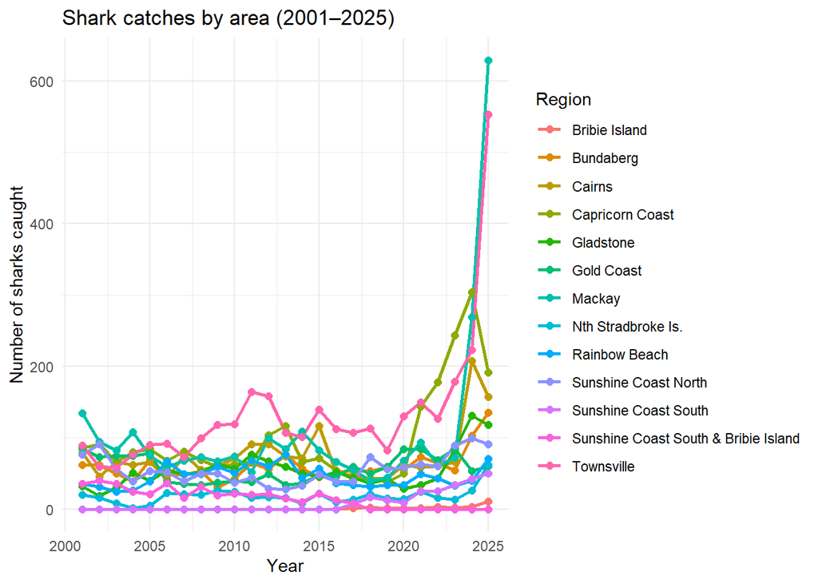

```r
ggplot(shark_tidy, aes(x = Year, y = Shark, colour = Area)) +
  geom_line(size = 1) +
  geom_point(size = 2) +
  labs(
    title = "Shark catches by area (2001–2025)",
    x = "Year",
    y = "Number of sharks caught",
    colour = "Region"
  ) +
  theme_minimal()
```

Figure 1. Time-series of shark catches across regions. This plot highlights both stable and fluctuating catch trends over time.

Part 4: Spatial visualization

For better visual comprehension I have decided to use R , to make geographical representation of the data for the year 2025 using the maps package .

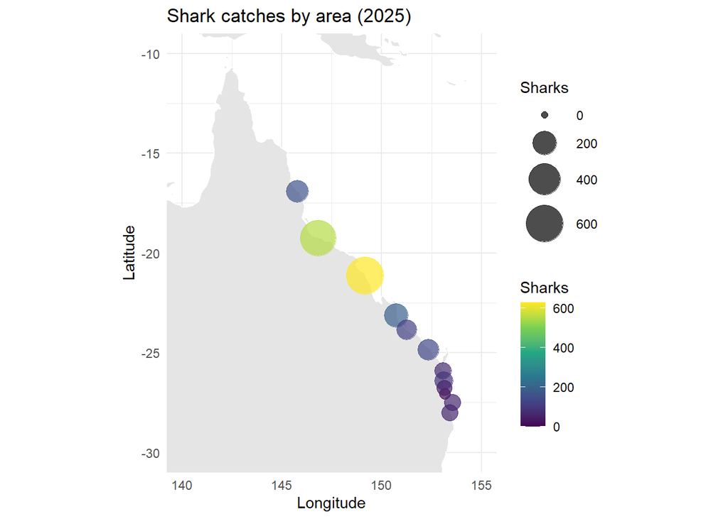

```r
library(maps)
#  Assign approximate lat/lon coordinates to SCP areas
area_coords <- tribble(
  ~Area,                 ~lat,    ~lon,
  "Bribie Island",      -27.07, 153.15,
  "Bundaberg",          -24.87, 152.35,
  "Cairns",             -16.92, 145.78,
  "Capricorn Coast",    -23.13, 150.73,
  "Gladstone",          -23.85, 151.25,
  "Gold Coast",         -28.02, 153.40,
  "Mackay",             -21.14, 149.18,
  "Nth Stradbroke Is.", -27.50, 153.53,
  "Rainbow Beach",      -25.91, 153.09,
  "Sunshine Coast North",-26.40, 153.10,
  "Sunshine Coast South",-26.75, 153.13,
  "Townsville",         -19.26, 146.82
)

# Filter shark data for a single year (e.g. 2020)
shark2020 <- shark_tidy %>% filter(Year == 2025)

# Merge shark catches with coordinates
shark_map <- left_join(shark2020, area_coords, by = "Area")

# Base world map from ggplot2
world <- map_data("world")

# Plot
ggplot() +
  geom_polygon(data = world, aes(x = long, y = lat, group = group),
               fill = "grey90", colour = "white") +
  geom_point(data = shark_map,
             aes(x = lon, y = lat, size = Shark, colour = Shark),
             alpha = 0.7) +
  scale_size_continuous(range = c(2, 12)) +
  scale_colour_viridis_c() +
  coord_fixed(xlim = c(140, 155), ylim = c(-30, -10)) +
  labs(title = "Shark catches by area (2025)",
       x = "Longitude", y = "Latitude",
       size = "Sharks", colour = "Sharks") +
  theme_minimal()
```

Figure 2. Shark catches by region in 2025. Circle size and colour both represent the number of sharks caught, with larger, brighter circles indicating higher catches

Discussion

Changes through time are harder to generalize. Year-to-year swings in catch reflect shifts in abundance, movement, and even local behavior, and they don’t always match total shark numbers. For example, east-coast studies have shown that tiger shark catch rates have dropped over the years (Holmes et al., 2012). That means that looking only at raw totals can mask species-level dynamics, and future work should push toward species-specific analysis and standardized indices like CPUE.

References

Cortés, E., Grubbs, R. D., Zárate, P., & Arocha, F. (2010). Vulnerability of pelagic sharks to longline fishing in the Atlantic Ocean. Marine and Freshwater Research, 61(6), 658–669. https://doi.org/10.1071/MF09179

Gibbs, L., & Warren, C. (2014). Transforming shark hazard management in Australia: Learning from oceanic whitetip conservation. Marine Policy, 46, 118–124. https://doi.org/10.1016/j.marpol.2014.01.017

(Note: The “original work published 1995” reference to NSW meshing bycatch is not a formal APA citation; this is the updated peer-reviewed paper by the same authors.)

Gribble, N. A., McPherson, G., & Lane, B. (2008). Effect of the Queensland Shark Control Program on non-target species: Whales, dugongs, turtles and dolphins. Queensland Department of Primary Industries and Fisheries. https://era.daf.qld.gov.au/id/eprint/7827/

Holmes, B. J., Sumpton, W. D., Mayer, D. G., Tibbetts, I. R., Neil, D. T., & Bennett, M. B. (2012). Declining trends in annual catch rates of the tiger shark (Galeocerdo cuvier) on the east coast of Australia. Fisheries Research, 129–130, 38–45. https://doi.org/10.1016/j.fishres.2012.06.005

Kyne, P. M., Carlson, J. K., Ebert, D. A., Fordham, S. V., Fowler, S. L., Pardo, S. A., Simpfendorfer, C. A., & Dulvy, N. K. (2021). The conservation status of global shark and ray fisheries. CSIRO/International Union for Conservation of Nature (IUCN). https://doi.org/10.25919/x9vr-vy93

Simpfendorfer, C. A. (1992). Biology of tiger sharks (Galeocerdo cuvier) caught by the Queensland shark meshing program off Townsville, Australia. Australian Journal of Marine and Freshwater Research, 43(1), 33–43. https://doi.org/10.1071/MF9920033

Sumpton, W. D., Taylor, S. M., Gribble, N. A., McPherson, G., & Ham, T. (2011). Gear selectivity of large-mesh nets and drumlines used to catch sharks in the Queensland Shark Control Program. African Journal of Marine Science, 33(1), 37–43. https://doi.org/10.2989/1814232X.2011.572335

Sporre, M. K., Chapman, D. D., Feldheim, K. A., & Shivji, M. S. (2011). Trends in annual CPUE and evidence of sex and size segregation of scalloped hammerheads (Sphyrna lewini) in the northwestern Atlantic Ocean. Marine and Coastal Fisheries, 3(1), 169–181. https://doi.org/10.1080/19425120.2011.572346